# Project 2 – Dataset 2: Congressional Seats by State

Matthew Lucich

```r
library(tidyverse)
library(ggplot2)
library(DT)
```

## Overview

The approach below starts off with loading CSV data from the Brookings Institution, titled *1-1 Apportionment of Congressional Seats, by Region and State, 1910 - 2010*. The dataset includes unnecessary headers, therefore the skip parameter is passed in while loading the dataframe. There are also several extraneous rows: either blank or containing notes. Those are cleared by simply filtering out rows where the state column is blank. Next, regions are removed via a vector, using "!" and "%in%" operators, as there is no scalable conditionals to target all regions. Using the pivot_longer function the data is transformed from having columns for each year to having one year column and the respective values in the cong_seats column. During data exploration the lag, lead functions are you used to calculate percentage decade over decade. Additionally, summarise is used to generate multiple calculated columns.

### Loading the data

```r
# Load congressional seats csv from Github URL
#df_cs_raw <- read.csv(url("https://raw.githubusercontent.com/mattlucich/data-transformation/seats/congressional-seats.csv"))

# Load congressional seats csv from Github repo (if you prefer)
df_cs_raw <- read.csv("congressional-seats.csv", skip = 3)

# Preview the data
glimpse(df_cs_raw)
```

```
## Rows: 68
## Columns: 12
## $ Region.and.State <chr> "South", "   Alabama", "   Arkansas", "   Florida", …
## $ X1910            <chr> "104", "10", "7", "4", "12", "8", "8", "10", "7", "1…
## $ X1920            <lgl> NA, NA, NA, NA, NA, NA, NA, NA, NA, NA, NA, NA, NA, …
## $ X1930            <int> 102, 9, 7, 5, 10, 8, 7, 11, 6, 9, 21, 9, NA, 43, 9, …
## $ X1940            <int> 105, 9, 7, 6, 10, 8, 7, 12, 6, 10, 21, 9, NA, 42, 9,…
## $ X1950            <chr> "106", "9", "6", "8", "10", "8", "6", "12", "6", "9"…
## $ X1960            <int> 106, 8, 4, 12, 10, 8, 5, 11, 6, 9, 23, 10, NA, 36, 7…
## $ X1970            <int> 108, 7, 4, 15, 10, 8, 5, 11, 6, 8, 24, 10, NA, 35, 7…
## $ X1980            <int> 116, 7, 4, 19, 10, 8, 5, 11, 6, 9, 27, 10, NA, 34, 7…
## $ X1990            <int> 125, 7, 4, 23, 11, 7, 5, 12, 6, 9, 30, 11, NA, 32, 6…
## $ X2000            <int> 131, 7, 4, 25, 13, 7, 4, 13, 6, 9, 32, 11, NA, 31, 6…
## $ X2010            <int> 138, 7, 4, 27, 14, 6, 4, 13, 7, 9, 36, 11, NA, 30, 6…
```

### Cleaning the data

```r
# Rename column
df_cs_raw <- df_cs_raw %>% rename(state = "Region.and.State")

# Filter out empty rows
df_cs_raw <- df_cs_raw %>% filter(state != "")

# Remove regions
remove_regions <- c("South", "Border", "New England", "Mid-Atlantic", "Midwest",
                    "Plains", "Rocky Mountains", "Pacific Coast")
df_cs_raw <- df_cs_raw %>% filter(!state %in% remove_regions)

# Remove columns with only NAs (1920s)
all_na_column <- function(x) any(!is.na(x))
df_cs_raw <- df_cs_raw %>% select(where(all_na_column))

# Convert all columns except "state" to numeric
df_cs_raw <- df_cs_raw %>% mutate(across(!state, as.numeric))
```

## Transforming the data

```r
# Gather year columns into one column "year" and their values to "cong_seats"
df_cs_long <- df_cs_raw %>%
                        pivot_longer(
                          cols = X1910:X2010,
                          names_to = "year",
                          values_to = "cong_seats",
                          values_drop_na = TRUE
                        )

# Remove the extraneous "X" in the year values
df_cs_long <- df_cs_long %>% mutate(year = sub("X", "", year))

# Preview the long format
datatable(df_cs_long, caption = "Congressional Seats by Year (long format)")
```

|  | state | year | cong_seats |
| --- | --- | --- | --- |
| 1 | Alabama | 1910 | 10 |
| 2 | Alabama | 1930 | 9 |
| 3 | Alabama | 1940 | 9 |
| 4 | Alabama | 1950 | 9 |
| 5 | Alabama | 1960 | 8 |
| 6 | Alabama | 1970 | 7 |
| 7 | Alabama | 1980 | 7 |
| 8 | Alabama | 1990 | 7 |
| 9 | Alabama | 2000 | 7 |
| 10 | Alabama | 2010 | 7 |

[output cut: 481 more lines]

### Congressional Seats by Year

```r
# Group by year and sum congressional seats
df_cs_year <- df_cs_long %>% group_by(year) %>%
                summarise(total_cs = sum(as.numeric(cong_seats)))

# Add change column to see which years had biggest increase
df_cs_year <- df_cs_year %>%
                mutate(perc_change = round((lead(total_cs) - lag(total_cs)) / lag(total_cs), 4))

# Wow, that was anticlimactic
datatable(df_cs_year, caption = "Congressional Seats by Decade")
```

|  | year | total_cs | perc_change |
| --- | --- | --- | --- |
| 1 | 1910 | 434 |  |
| 2 | 1930 | 435 | 0.0023 |
| 3 | 1940 | 435 | 0 |
| 4 | 1950 | 435 | 0 |
| 5 | 1960 | 435 | 0 |
| 6 | 1970 | 435 | 0 |
| 7 | 1980 | 435 | 0 |
| 8 | 1990 | 435 | 0 |
| 9 | 2000 | 435 | 0 |
| 10 | 2010 | 435 |  |

### Congressional Seats by State

```r
# Group by state and create latest, median, max, mix, and total columns
df_cs_state <- df_cs_long %>% group_by(state) %>%
                    summarise(latest_cs = last(cong_seats),
                              median_cs = median(cong_seats),
                              max_cs = max(cong_seats),
                              min_cs = min(cong_seats),
                              total_cs = sum(cong_seats))

datatable(df_cs_state, caption = "Congressional Seats by State")
```

|  | state | latest_cs | median_cs | max_cs | min_cs | total_cs |
| --- | --- | --- | --- | --- | --- | --- |
| 1 | Alabama | 7 | 7.5 | 10 | 7 | 80 |
| 2 | Alaska | 1 | 1 | 1 | 1 | 6 |
| 3 | Arizona | 9 | 3.5 | 9 | 1 | 41 |
| 4 | Arkansas | 4 | 4 | 7 | 4 | 51 |
| 5 | California | 53 | 40.5 | 53 | 11 | 368 |
| 6 | Colorado | 7 | 4.5 | 7 | 4 | 51 |
| 7 | Connecticut | 5 | 6 | 6 | 5 | 57 |
| 8 | Delaware | 1 | 1 | 1 | 1 | 10 |
| 9 | Florida | 27 | 13.5 | 27 | 4 | 144 |
| 10 | Georgia | 14 | 10 | 14 | 10 | 110 |

[output cut: 40 more lines]

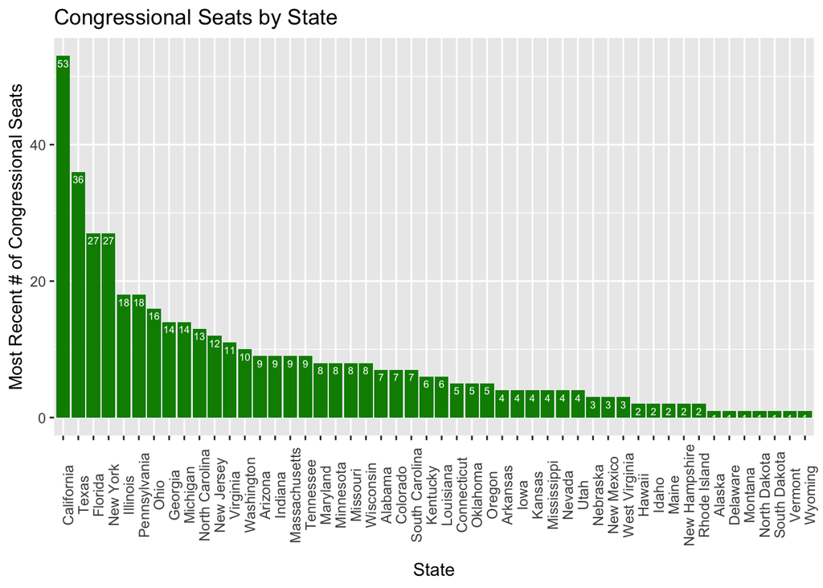

```r
# Histogram: Congressional seats by state
ggplot(df_cs_state, aes(x=reorder(state, -latest_cs), weights=latest_cs)) +
  geom_bar(fill="green4") + theme(axis.text.x = element_text(angle = 90)) +
  geom_text(aes(label=latest_cs, y=latest_cs), vjust=1.5, color="white", size=2.2) +
  ggtitle("Congressional Seats by State") +
  ylab("Most Recent # of Congressional Seats") + xlab("State")
```

## Conclusion

This dataset was chosen mainly for its unique structure that fits perfectly with the projects objectives of loading, tidying, and transforming datasets. Unfortunately, the lack of attributes made the analysis anticlimactic. The Brookings Institution also offers data with the percent breakout between political parties over time, which may make for a more interesting follow-up analysis. In the meantime, the tables and histogram above give us an informative view of how each state compares in terms of congressional representation as well as how that has changed over the decades.

## References

*Vital Statistics*, The Brookings Institution ["1-1 Apportionment of Congressional Seats, by Region and State, 1910 - 2010 (435 seats)"](https://www.brookings.edu/multi-chapter-report/vital-statistics-on-congress/)

This work is licensed under a [Creative Commons Attribution-ShareAlike 4.0 International License](http://creativecommons.org/licenses/by-sa/4.0/).